# Конспект по комбинаторике

Alexander Botvin

14 08 2021

## Оглавление

1.Правило суммы  
2.Правило произведения  
3.Стандартные задачи  
4.Решение задач. Комбинаторика  
5.Решение задач. Сравнение количеств  
6.Решение задач. Подсчёты с кратностью  
Решение прочих задач

## 1. Правило суммы

Для того чтобы посчитать каким количеством способов можно что-то сделать для любой одной единицы из всего множества.  
**Пример**: В 𝑛 ящиках лежат 𝑁1, . . . ,𝑁𝑘 различимых шаров. Сколько имеется способов вытащить из этих ящиков один шар?

$N_{1}+N_{2}+N_{k}$

## 2. Правило произведения

Для того чтобы посчитать каким количеством способов можно выбрать по каждому объекту из множеств.  
**Пример**: В 𝑛 ящиках лежат 𝑁1, . . . ,𝑁𝑘 различимых шаров. Сколько имеется способов вытащить из этих ящиков 𝑘 шаров, вынимая из каждого ящика по одному шару?

$N_{1}*N_{2}*N_{k}$

## 3. Стандартные задачи

[output not shown]

Коммент: размещения и сочетания на первый взгляд похожи. Но в сочетаниях нам нет дела до порядка - это одни и теже комбинации, а в размещении есть.

**Подмножеств в множестве:** $2^n$ (идея с вхождениями с 0 и 1)  
**Биномиальное тождество** $n * 2^n-^1$

## 4. Решение задач. Комбинаторика

**Задача 1:** В магазине имеются 3 красных, 5 зеленых и 4 голубых шапки, а также шарфы трех цветов: 7 красных, 2 зеленых и 5 голубых. а) Сколькими способами Маша может выбрать себе шапку и шарф? б) А сколькими способами можно выбрать шапку и шарф одного цвета? в) Разных цветов?

**Решение 1:** по правилу суммы и произведения

```r
red_hat <- 3
green_hat <- 5
blue_hat <- 4

red_scarf <- 7
green_scarf <- 2
blue_scarf <- 5

#a) Сколькими способами Маша может выбрать себе шапку и шарф?
red_hat + green_hat + blue_hat + red_scarf + green_scarf + blue_scarf
```

```
## [1] 26
```

```r
#б) А сколькими способами можно выбрать шапку и шарфодного цвета?
red_hat * red_scarf + green_hat * green_scarf + blue_hat * blue_scarf
```

```
## [1] 51
```

```r
#в) Разных цветов?
red_hat * green_scarf * blue_scarf + green_hat * red_scarf * blue_scarf + blue_hat * red_scarf * green_scarf
```

```
## [1] 261
```

**Задача 2:** Сколькими способами можно выбрать 4 краски из имеющихся 7 различных?

**Решение 2:** стандартная задача, сочетания без повторений

```r
n <- 7
k <- 4

factorial(n) / (factorial(n-k) * factorial(k))
```

```
## [1] 35
```

**Задача 3:** Автобусные билеты имеют шестизначные номера, от 000000 до 999999. Сколько существует номеров а) все цифры которых четны? б) в которых любые две соседние цифры различны? в) все цифры которых различны? г) в которых есть не менее двух одинаковых цифр? д) содержащих цифру 7? е) в которых есть хотя бы одна четная цифра? ж) в которых ровно две одинаковые цифры? з) в которых цифры 1, 2, 3 встречаются ровно по одному разу?

**Решение 3:** стандартная задача, размещения с повторениями / без повторений и др.

```r
all_digits <- length(c(0,1,2,3,4,5,6,7,8,9))
even_digits <- length(c(0,2,4,6,8))
slots <- nchar('000000')
#справочно всего комбинация из всех цифр
n <- all_digits
k <- slots

prettyNum(n^k,big.mark=" ",scientific=FALSE)
```

```
## [1] "1 000 000"
```

```r
#а) все цифры которых четны?
n <- even_digits
k <- slots

prettyNum(n^k,big.mark=" ",scientific=FALSE)
```

```
## [1] "15 625"
```

```r
#б) в которых любые две соседние цифры различны?
n <- all_digits
k_1 <- slots-2
k_2 <- slots-4
prettyNum( (factorial(n) / factorial(n-k_2)) * n^k_1,big.mark=" ",scientific=FALSE)
```

```
## [1] "900 000"
```

```r
#в) все цифры которых различны
n <- all_digits
k <- slots
prettyNum(factorial(n) / factorial(n-k) ,big.mark=" ",scientific=FALSE)
```

```
## [1] "151 200"
```

```r
#г) в которых есть не менее двух одинаковых цифр?
same <- length(c(0==0,1==1,2==2,3==3,4==4,5==5,6==6,7==7,8==8, 9==9))

n <- all_digits
k <- slots-2
prettyNum(n^k * same ,big.mark=" ",scientific=FALSE)
```

```
## [1] "100 000"
```

```r
#д) содержащих цифру 7?
n <- all_digits
k <- slots

all_combination <- n^k
without_seven <- (n-1)^k

prettyNum(all_combination -  without_seven, big.mark=" ",scientific=FALSE)
```

```
## [1] "468 559"
```

```r
#е) в которых есть хотя бы одна четная цифра?
n_1 <- all_digits
k_1 <- slots - 1
n_2 <- even_digits
k_2 <- slots-5

prettyNum(n_1^k_1 * n_2^k_2, big.mark=" ",scientific=FALSE)
```

```
## [1] "500 000"
```

```r
#ж) в которых ровно две одинаковые цифры?
same <- length(c(0==0,1==1,2==2,3==3,4==4,5==5,6==6,7==7,8==8, 9==9))

n <- all_digits-1
k <- slots-2
prettyNum(n^k * same ,big.mark=" ",scientific=FALSE)
```

```
## [1] "65 610"
```

```r
#з) в которых цифры 1, 2, 3 встречаются ровно по одному разу?
n <- all_digits-3
k <- slots-3
prettyNum(factorial(3) *  n^k ,big.mark=" ",scientific=FALSE)
```

```
## [1] "2 058"
```

**Задача 4:** Автомобильные номера в одном регионе РФ состоят либо из 3 букв и 3 цифр, либо из 2 букв и 4 цифр, при этом порядок следования букв и цифр в номере фиксирован. Из букв используются не все, а только а, в, е, к, м, н, о, р, с, т, у, х. Какое максимальное число автомобилей может быть в одном регионе?

**Решение 4:** стандартная задача, размещения с повторениями и др.

```r
all_digits <- length(c(0,1,2,3,4,5,6,7,8,9))
all_letters <- length(c('a','в','е','к','м','н','о','р','с','т','у','х'))

n_digits <- all_digits
k_digits_first <- 3
k_digits_second <- 4

n_letters <- all_letters
k_letters_first <- 3
k_letters_second <- 2

first_digits <- n_digits^k_digits_first
first_letters <- n_letters^k_letters_first

second_digits <- n_digits^k_digits_second
second_letters <- n_letters^k_letters_second

prettyNum( ((first_digits * first_letters) + (second_digits * second_letters)  ),big.mark=" ",scientific=FALSE)
```

```
## [1] "3 168 000"
```

**Задача 5:** а) В стране три города: Астрахань, Белозерск и Владимир. Из Астрахани в Белозерск ведeт 5 дорог, а из Белозерска во Владимир – 4 дороги. Сколькими способами можно проехать из Астрахани во Владимир? б) В стране построили город Гусь-Хрустальный и несколько новых дорог: две из Астрахани в Гусь-Хрустальный и две из Гуся-Хрустального во Владимир. Сколькими способами можно теперь проехать из Астрахани во Владимир?

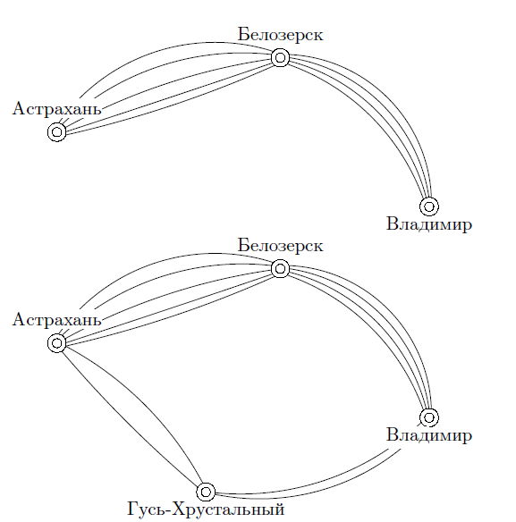

**Решение 5:** по правилу произведения

```r
Ast_Bel <- 5
Bel_Vla <- 4
Ast_Gus <- 2
Gus_Vla <- 2

#а) В стране три города: Астрахань, Белозерск и Владимир. Из Астрахани в Белозерск ведeт 5 дорог, а из Белозерска во Владимир – 4 дороги. Сколькими способами можно проехать из Астрахани во Владимир?
prettyNum(Ast_Bel * Bel_Vla ,big.mark=" ",scientific=FALSE)
```

```
## [1] "20"
```

```r
#б) В стране построили город Гусь-Хрустальный и несколько новых дорог: две из Астрахани в Гусь-Хрустальный и две из Гуся-Хрустального во Владимир. Сколькими способами можно теперь проехать из Астрахани во Владимир?
prettyNum( (Ast_Bel * Bel_Vla) + (Ast_Gus * Gus_Vla) ,big.mark=" ",scientific=FALSE)
```

```
## [1] "24"
```

**Задача 6:** В 7б классе работают три преподавателя: Алексей Анатольевич, Дмитрий Викторович и Андрей Юрьевич. Обращаясь к преподавателю, Ваня обычно меняет его имя на имя другого преподавателя, либо меняет отчество на отчество другого преподавателя, либо и то, и другое вместе. а) Сколькими способами он может позвать преподавателя? б) Сколькими способами он может это сделать, если стало известно, что он может менять местами имя и отчество (то есть назвать Алексея Анатольевича Анатолием Алексеевичем или Виктором Дмитриевичем)?

**Решение 6:** по правилу произведения

```r
# а) Сколькими способами он может позвать преподавателя?
first_name <- 3
last_name <- 3
prettyNum( first_name * last_name,big.mark=" ",scientific=FALSE)
```

```
## [1] "9"
```

```r
#б) Сколькими способами он может это сделать, если стало известно, что он может менять местами имя и отчество (то есть назвать Алексея Анатольевича Анатолием Алексеевичем или Виктором Дмитриевичем)?
prettyNum( (first_name * last_name) * 2,big.mark=" ",scientific=FALSE)
```

```
## [1] "18"
```

**Задача 7:** а) Сколько можно составить разных (не обязательно осмысленных) слов из k букв, используя русский алфавит? б) А если потребовать, чтобы буквы в словах не повторялись? в) Сколькими способами можно переставить буквы в слове из k различных букв?

**Решение 7:** стандартная задача, размещение и перемещение

```r
# а) Сколько можно составить разных (не обязательно осмысленных) слов из k букв, используя русский алфавит?
n <- 33
k <- 5
prettyNum( n^5,big.mark=" ",scientific=FALSE)
```

```
## [1] "39 135 393"
```

```r
#б) А если потребовать, чтобы буквы в словах не повторялись?
prettyNum(factorial(n) / factorial(n-k),big.mark=" ",scientific=FALSE)
```

```
## [1] "28 480 320"
```

```r
#в) Сколькими способами можно переставить буквы в слове из k различных букв?
factorial(k)
```

```
## [1] 120
```

**Задача 8:** 33 богатыря решили продемонстрировать Черномору все возможные построения.Каждую секунду они перестраиваются по-новому. Смогут ли они показать Черномору все построения за один час? За один день? За один год? За один век?

**Решение 8:** перемещение без повторений

```r
n <- 33
all_positions <- factorial(n)

prettyNum(all_positions / 60 / 60 / 24 / 365 / 100,big.mark=" ",scientific=FALSE)
```

```
## [1] "2 753 461 954 214 829 453 448 840 048"
```

**Задача 9:** Световое табло состоит из лампочек, каждая из которых может быть включена или выключена. Какое наименьшее количество лампочек должно находиться на табло, чтобы с его помощью можно было передать 100 различных сигналов?

**Решение 9:** размещение с повторением

```r
n <- 2
k <- 100

n^7>k
```

```
## [1] TRUE
```

```r
prettyNum(7,big.mark=" ",scientific=FALSE)
```

```
## [1] "7"
```

**Задача 10:** а) Для передачи сигналов на флоте используют специальные сигнальные флаги определенных видов. На корабле имеется большое количество флагов каждого вида. На мачту можно вывесить последовательность из трех флагов. Сколько можно таким образом передать сигналов, если количество различных видов флагов равно 10? б) Какое количество разных видов флагов должно быть на корабле (флагов каждого вида при этом много), чтобы с их помощью можно было передать не менее 50 различных сигналов?

**Решение 10:** размещение с повторением

```r
#а) Для передачи сигналов на флоте используют специальные сигнальные флаги определенных видов. На корабле имеется большое количество флагов каждого вида. На мачту можно вывесить последовательность из трех флагов. Сколько можно таким образом передать сигналов, если количество различных видов флагов равно 10?
n <- 10
k <- 3

prettyNum(n^k,big.mark=" ",scientific=FALSE)
```

```
## [1] "1 000"
```

```r
#б) Какое количество разных видов флагов должно быть на корабле (флагов каждого вида при этом много), чтобы с их помощью можно было передать не менее 50 различных сигналов?

4^3 >= 50
```

```
## [1] TRUE
```

```r
prettyNum(4,big.mark=" ",scientific=FALSE)
```

```
## [1] "4"
```

**Задача 11:** а) В заборе 20 досок, каждую надо покрасить в синий, зеленый или желтый цвет, причем соседние доски красятся в разные цвета. Сколькими способами это можно сделать? б) А если требуется еще, чтобы хоть одна из досок обязательно была синей?

**Решение 11:**

```r
#а) В заборе 20 досок, каждую надо покрасить в синий, зеленый или желтый цвет, причем соседние доски красятся в разные цвета. Сколькими способами это можно сделать?
k <- 20
n <- 3
all_combination <- n * (n-1)^(k-1)

prettyNum(all_combination,big.mark=" ",scientific=FALSE)
```

```
## [1] "1 572 864"
```

```r
#б) А если требуется еще, чтобы хоть одна из досок обязательно была синей?
prettyNum(all_combination-2,big.mark=" ",scientific=FALSE)
```

```
## [1] "1 572 862"
```

**Задача 12:** а) Сколькими способами можно поставить на шахматную доску белую и черную ладьи так, чтобы они не били друг друга? б) Тот же вопрос для двух королей.

**Решение 12:**

```r
#а) Сколькими способами можно поставить на шахматную доску белую и черную ладьи так, чтобы они не били друг друга?
desk <- 8*8

white_fig <- desk
black_fig <- white_fig - 1
all_variants_fig <- 7 * 2

prettyNum(white_fig * (black_fig - all_variants_fig), big.mark=" ",scientific=FALSE)
```

```
## [1] "3 136"
```

```r
#б) Тот же вопрос для двух королей
corners <- 4
variants_corners <- corners * (desk-corners)

borders <- 24
variants_borders <- borders * (desk-6)

remain <- desk - corners - borders
variants_remain <- remain * (desk-9)


prettyNum(variants_corners + variants_borders + variants_remain, big.mark=" ",scientific=FALSE)
```

```
## [1] "3 612"
```

**Задача 13:** Сколькими способами можно расставить на шахматной доске 8 различных ладей так, чтобы они не били друг друга?

**Решение 13:**

```r
n <- 8

prettyNum(factorial(n), big.mark=" ",scientific=FALSE)
```

```
## [1] "40 320"
```

**Решение 14:** а) Сколько различных строк можно составить из 0 и 1, чтобы в каждой строке было 8 цифр? б) На столе 8 различных конфет. Сколькими способами можно съесть несколько из них? в) Сколькими способами можно распределить 8 вновь пришедших учеников по трем классам?

```r
#а) Сколько различных строк можно составить из 0 и 1, чтобы в каждой строке было 8 цифр?
n <- 2
k <- 8

prettyNum(n^k, big.mark=" ",scientific=FALSE)
```

```
## [1] "256"
```

```r
#б) На столе 8 различных конфет. Сколькими способами можно съесть несколько из них?
n <- 8
factorial(n)
```

```
## [1] 40320
```

```r
#в) Сколькими способами можно распределить 8 вновь пришедших учеников по трем классам?
n <- 3
k <- 8

prettyNum(n^k, big.mark=" ",scientific=FALSE)
```

```
## [1] "6 561"
```

**Задача 15:** Меню в школьном буфете постоянно и состоит из n разных блюд. Петя хочет каждый день выбирать себе завтрак по-новому (за раз он может съесть от 0 до n разных блюд). а) Сколько дней ему удастся это делать? б) Сколько блюд он съест за это время?

**Решение 15:**

```r
#а) Сколько дней ему удастся это делать?
n <- 6 #предположим, что 6 блюд

prettyNum(2^n, big.mark=" ",scientific=FALSE)
```

```
## [1] "64"
```

```r
#б) Сколько блюд он съест за это время?

prettyNum(n * 2^(n-1), big.mark=" ",scientific=FALSE)
```

```
## [1] "192"
```

**Задача 16:** На полке стоят 5 книг. Сколькими способами можно выложить в стопку несколько из них (стопка может состоять и из одной книги)?

**Решение 16:**

```r
n <- 5

res_list <- c()

for (k in 1:5){
  res <- factorial(n) / factorial(n-k)
  res_list <- append(res_list, res)
}

prettyNum(sum(res_list), big.mark=" ", scientific=FALSE)
```

```
## [1] "325"
```

**Задача 17:** Сколькими способами можно покрасить квадрат 2 x 2, составленный из 4 квадратиков, если каждый квадратик надо покрасить в один из n цветов, и соседние (имеющие общую сторону) квадратики должны быть покрашены по-разному?

**Решение 17:**

```r
k <- 4
n <- 4

all_combination <- n * (n-1)^(k-1)

prettyNum(all_combination,big.mark=" ",scientific=FALSE)
```

```
## [1] "108"
```

**Задача 18:** а) Сколькими способами можно разбить 7 юношей и 7 девушек на пары для танцев? б) 14 школьников на пары?

**Решение 18:**

```r
#а) Сколькими способами можно разбить 7 юношей и 7 девушек на пары для танцев?
boys <- 7
girls <- 7

prettyNum(factorial(boys), big.mark=" ",scientific=FALSE)
```

```
## [1] "5 040"
```

```r
#б) 14 школьников на пары?
n <- boys + girls
k <- 2

prettyNum(13 * 11 * 9 * 7 * 5 * 3 * 1, big.mark=" ",scientific=FALSE)
```

```
## [1] "135 135"
```

**Задача 19:** В таблицу размера k * l записывают числа +1 и 1 так, чтобы произведение чисел в каждой строке и в каждом столбце равнялось 1. Сколькими способами это можно сделать?

**Решение 19:**

```r
#не уверен в решении

prettyNum(2^15, big.mark=" ",scientific=FALSE)
```

```
## [1] "32 768"
```

**Решение 20:** [Нужно заполнять таблицу, смотри здесь](https://www.problems.ru/view_problem_details_new.php?id=79614)

## 5. Решение задач. Сравнение количеств

**Задача 1:** В зале 8 светильников. Сравните количество способов включить ровно 5 из них с количеством различных слов, которые можно получить из слова АХАХАХАА, переставляя в нем буквы.

**Решение 1:** сочетания без повторений + перестановки с повторениями

```r
n <- 8
k <- 5
lamps <- factorial(n) / (factorial(n-k) * factorial(k))

n_all <- nchar('АХАХАХАА')
n_a <- nchar('ААААА')
n_h <- nchar('ХХХ')

letters <- factorial(n_all) / (factorial(n_a) * factorial(n_h))

prettyNum(letters > lamps, big.mark=" ",scientific=FALSE)
```

```
## [1] "FALSE"
```

```r
prettyNum(letters < lamps, big.mark=" ",scientific=FALSE)
```

```
## [1] "FALSE"
```

```r
prettyNum(letters == lamps, big.mark=" ",scientific=FALSE)
```

```
## [1] "TRUE"
```

**Задача 2:** Город имеет форму прямоугольника 3 x 5, разбитого улицами на кварталы 1 x 1. Сравните количество кратчайших путей, которые ведут из левого нижнего угла в правый верхний, с количествами из предыдущей задачи.

**Решение 2**

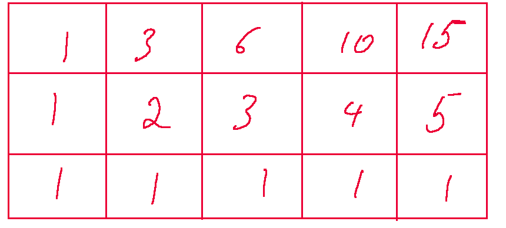

```r
ways <- 15
prettyNum(ways, big.mark=" ",scientific=FALSE)
```

```
## [1] "15"
```

**Задача 3:** а) Сравните количество решений уравнения x + y + z + t = 5 в натуральных числах и количество решений этого же уравнения в целых неотрицательных числах. Каких решений больше? б) Совпадает ли какое-то из этих количеств с количествами из двух предыдущих задач?

**Решение 3** сочетания с повторениями

```r
n <- 5
k <- 4
integer_v <- factorial(n+k-1) / (factorial(n) * factorial(k-1))

prettyNum(integer_v, big.mark=" ",scientific=FALSE)
```

```
## [1] "56"
```

```r
#положим по одной 1 в каждый ящик
n <- 5-4
k <- 4
nature_v <- factorial(n+k-1) / (factorial(n) * factorial(k-1))
prettyNum(nature_v, big.mark=" ",scientific=FALSE)
```

```
## [1] "4"
```

**Задача 4:** У Маши и Даши есть мешок с конфетами 9 видов. К Новому году Маша составляет различные наборы, в каждом из которых 4 конфеты разного вида, а Даша — аналогичные наборы, но из 5 конфет. У какой из девочек получится составить больше наборов?

**Решение 4** сочетания без повторений

```r
n <- 9
k <- 4

prettyNum(factorial(n) / (factorial(n-k) * factorial(k)), big.mark=" ",scientific=FALSE)
```

```
## [1] "126"
```

```r
k <- 5
prettyNum(factorial(n) / (factorial(n-k) * factorial(k)), big.mark=" ",scientific=FALSE)
```

```
## [1] "126"
```

**Задача 5:** У Маши и Даши на кухне есть черный и белый хлеб, сдобные булочки, вареная и копченая колбаса, ветчина, «Российский» сыр, плавленый сыр, масло, кетчуп и майонез. К празднику они решили приготовить как можно больше бутербродов различного вида. Маша делает все бутерброды без масла, а Даша — исключительно с маслом. У какой из девочек получится сделать больше видов бутербродов? (Бутерброды, отличающиеся только порядком ингредиентов или их количеством, считаются одинаковыми.)

**Решение 5**

```r
n1 <- 3
n2 <- 8
n3 <- 7

prettyNum(3*7, big.mark=" ",scientific=FALSE)
```

```
## [1] "21"
```

```r
prettyNum(3*8, big.mark=" ",scientific=FALSE)
```

```
## [1] "24"
```

**Задача 6:** Учительница подготовила к уроку 10 примеров. Она хочет выдать Пете и Васе на дом задания, составленные из этих примеров так, чтобы им достались разные примеры. (Порядок примеров в задании не важен, количество примеров в заданиях может быть различным, не обязательно раздавать все примеры. Так, возможен случай, когда Пете не будет задано ни одного примера, а Васе все 10 или тоже ни одного.) Докажите, что количество способов, которыми она может это сделать, равно количеству различных последовательностей из нулей, единиц и двоек длины 10.

**Решение 6**

```r
#Не понятно как решать
n <- 10

#Всего вариантов раздаче всех заданий
2^n
```

```
## [1] 1024
```

**Задача 7:** Докажите, что если учительница из предыдущей задачи захочет выдать Пете и Васе задания так, чтобы Вася получил все те примеры, которые получил и Петя, а также, возможно, и какие-то еще, то количество способов это сделать будет таким же, как и в предыдущей задаче

**Решение 7**

**Задача 8:** У Пети и Васи есть по одинаковому набору из 12 кубиков: 3 красных, 3 синих, 3 желтых и 3 зеленых. Петя строит из всех своих кубиков башню, а Вася — стену размером 3 x 4. При этом оба хотят, чтобы любые два соседних по грани кубика в их постройках имели разный цвет. Кто из них может соорудить больше различных построек?

**Решение 8**

```r
n <- 4
k <- 12

#башня
tower <- n * (n-1)^(k-1)
prettyNum(tower, big.mark=" ",scientific=FALSE)
```

```
## [1] "708 588"
```

```r
#кубики
cubes <- n * (n-1)^(k-1)
prettyNum(cubes, big.mark=" ",scientific=FALSE)
```

```
## [1] "708 588"
```

**Задача 9:** Каких способов больше: расселить пять друзей на ночь в трех комнатах (гостиной, спальне и на кухне) или раздать пять одинаковых карамелек трем детям?

**Решение 9**

```r
n <- 5
k <- 3

friends <- k^n

prettyNum(friends, big.mark=" ",scientific=FALSE)
```

```
## [1] "243"
```

```r
candys <- factorial(n+k-1) / (factorial(n) * factorial(k-1))

prettyNum(candys, big.mark=" ",scientific=FALSE)
```

```
## [1] "21"
```

**Задача 10:** Каких способов больше: выбрать из 10 человек пять в команду по мини-футболу или разбить их на две равные команды по мини-футболу?

**Решение 10**

```r
n <- 10
k <- 5

team <- factorial(n) / (factorial(n-k) * factorial(k))
prettyNum(team, big.mark=" ",scientific=FALSE)
```

```
## [1] "252"
```

```r
#Две равные (что бы не учитывать дважды, нужно первое решение просто поделить на 2)
prettyNum(team/2, big.mark=" ",scientific=FALSE)
```

```
## [1] "126"
```

**Задача 11:** Некоторое число делится на 2, но не делится на 4. Каких делителей у него больше: четных или нечетных? (1 и само число тоже считаются делителями)

**Решение 11** поровну, *непонятно, как доказывать*

**Задача 12:** а) На окружности отмечено 100 синих точек и одна красная. Чего больше: треугольников с вершинами в синих точках или четырехугольников, одна из вершин которых красная, а три синие? б) Многоугольников, все вершины которых синие, или многоугольников, у которых одна из вершин красная?

**Решение 12** кажется, что треугольников больше

**Задача 13:** Меню школьной столовой постоянно и состоит из 11 блюд. Петя и Вася решили поспорить, кто из них дольше сможет питаться в школьной столовой. Условия спора следующие: Петя каждый день съедает четное число блюд (возможно, что и ни одного), а Вася — нечетное, причем каждый день необходимо съедать новый набор блюд. Кто из них победит в споре?

**Решение 13** у Васи больше, потому как у Пети будут 0 блюда

**Задача 14:** А кто победит в споре, если блюд будет 10?

**Решение 14** кажется, что поровну

**Задача 15:** Предположим, что одно из блюд в столовой — компот. Кто из них выпьет больше компотов за время спора в каждом из случаев?

**Решение 15** не понятно

**Задача 16:** В одной деревне 10 юношей и 10 девушек. Для одного танца нужно из этих 20 молодых людей выбрать группу, в которой поровну юношей и девушек, а для другого — просто выбрать группу из 10 молодых людей. Каждый день они танцуют как первый танец, так и второй (оба по одному разу), причем и тот, и другой — по-новому. Могут ли они за некоторое количество дней станцевать первый танец всеми способами, станцевав при этом всеми способами и второй танец?

**Решение 16**

```r
boys <- 10
girls <- 10

#Первый танец


#Второй танец
n <- boys + girls
k <- 10

factorial(n) / (factorial(n-k) * factorial(k))
```

```
## [1] 184756
```

**Задача 17:** а) Каких способов больше: раздать 10 пирожков с повидлом четырем школьникам или разложить 10 одинаковых синих шариков по 4 одинаковым картонным коробкам? б) Совпадает ли какое-нибудь из этих количеств с количеством решений уравнения x + y + z + t = 10 в целых неотрицательных числах?

**Решение 17**

```r
#а) Каких способов больше: раздать 10 пирожков с повидлом четырем школьникам или разложить 10 одинаковых синих шариков по 4 одинаковым картонным коробкам?

n <- 10
k <- 4

prettyNum(factorial(n+k-1) / (factorial(n) * factorial(k-1)), big.mark=" ",scientific=FALSE)
```

```
## [1] "286"
```

```r
#б) Совпадает ли какое-нибудь из этих количеств с количеством решений уравнения x + y + z + t = 10 в целых неотрицательных числах?
prettyNum(factorial(n+k-1) / (factorial(n) * factorial(k-1)), big.mark=" ",scientific=FALSE)
```

```
## [1] "286"
```

**Задача 18:** Сравните количество способов раздать 20 конфет шести детям так, чтобы каждый получил хотя бы одну конфету и количество способов раздать 15 конфет тем же детям, если некоторым из них можно вообще не давать конфет.

**Решение 18**

```r
k <- 6
n <- 20 - k
twenty <- prettyNum(factorial(n+k-1) / (factorial(n) * factorial(k-1)), big.mark=" ",scientific=FALSE)
twenty
```

```
## [1] "11 628"
```

```r
n <- 15
k <- 6

fifteen <- prettyNum(factorial(n+k-1) / (factorial(n) * factorial(k-1)), big.mark=" ",scientific=FALSE)
fifteen
```

```
## [1] "15 504"
```

**Задача 19:** При каком значении a количество решений уравнения x + y + z + t = 10 в целых неотрицательных числах равно количеству решений уравнения x + y + z + t = a в натуральных числах?

**Решение 19**

```r
n <- 10
k <- 4
integer_v <- factorial(n+k-1) / (factorial(n) * factorial(k-1))

prettyNum(integer_v, big.mark=" ",scientific=FALSE)
```

```
## [1] "286"
```

```r
#положим по одной 1 в каждый ящик
a <- 14
n <- a-4
k <- 4
nature_v <- factorial(n+k-1) / (factorial(n) * factorial(k-1))
prettyNum(nature_v, big.mark=" ",scientific=FALSE)
```

```
## [1] "286"
```

**Задача 20:** Придумайте уравнение, количество решений которого в натуральных числах было бы равно числу способов расположить в ряд 4 черных и 10 белых шаров так, чтобы никакие два черных шара не лежали рядом.

**Решение 20**

**Задача 21:** Каких чисел больше среди всех чисел от 100 до 999: тех, у которых средняя цифра больше обеих крайних, или тех, у которых средняя цифра меньше обеих крайних?

**Решение 21**

**Задача 22:** Придворный астролог царя Гороха называет время суток хорошим, если на часах с секундной стрелкой при мгновенном обходе циферблата по ходу часов минутная стрелка встречается после часовой и перед секундной, а плохим, если стрелки расположены в обратном порядке. Какого времени в сутках больше: хорошего или плохого?

**Решение 22**

**Задача 23:** Дана шахматная доска. Ее вертикали перенумерованы числами от 1 до 8, а горизонтали обозначены латинскими буквами от a до h. Рассматриваются покрытия доски доминошками, содержащими две соседние клетки3. Каких разбиений больше — тех, которые содержат доминошку a1-a2, или тех, которые содержат доминошку b2-b3?

**Решение 23**